# SWI4 Part 2:

Pratik Patil

17/10/2020

We are going to analyze the ToothGrowth data in the R datasets package.

Question 1: Load the ToothGrowth data and perform some basic exploratory data analyses

Plot the length against the dose for each of the supplements. In order to gain a better view of growth rates, we also add a curve. It is seen that the growth rates seem to behave differently for both supplements.

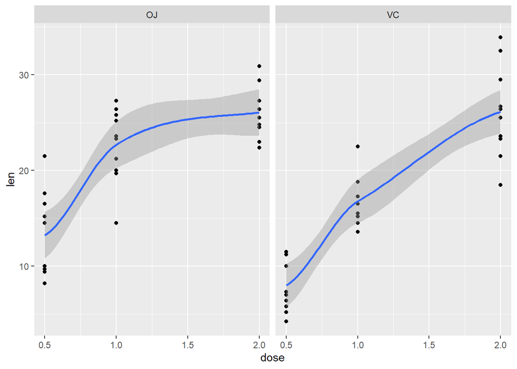

```r
library(ggplot2)
data(ToothGrowth)
qplot(dose, len, data=ToothGrowth, facets=.~supp, geom=c("point", "smooth"), method="loess")
```

Question 2: Provide a basic summary of the data.

This dataset contains three variables: supplement, dose and len. For each supplement, and each dose we calculate basic descriptive statistics: standard deviation, variance, and mean.

```r
dose <- as.numeric(levels(as.factor(ToothGrowth$dose)))
supp <- levels(ToothGrowth$supp)
# Structured for further processing
ls <- list()
y <- Map(function(s) {
  Map(function(d) {
    l <- ToothGrowth$len[ToothGrowth$dose == d & ToothGrowth$supp == s]
    ls <<- rbind(ls, list(supp = s, dose = d, sd=sd(l), var=var(l), mu=mean(l)))
  }, dose)
}, supp)
ls
```

```
##      supp dose sd       var      mu
## [1,] "OJ" 0.5  4.459709 19.889   13.23
## [2,] "OJ" 1    3.910953 15.29556 22.7
## [3,] "OJ" 2    2.655058 7.049333 26.06
## [4,] "VC" 0.5  2.746634 7.544    7.98
## [5,] "VC" 1    2.515309 6.326778 16.77
## [6,] "VC" 2    4.797731 23.01822 26.14
```

Question 3: Use confidence intervals and hypothesis tests to compare tooth growth by supp and dose. (Use the techniques from class even if there’s other approaches worth considering)

We perform the student-t test for each dose level between the two supplements:

```r
tests = list()
for (d in dose) {
  ojd <- ToothGrowth$len[ToothGrowth$dose == d & ToothGrowth$supp == "OJ"]
  vcd <- ToothGrowth$len[ToothGrowth$dose == d & ToothGrowth$supp == "VC"]
  t <- t.test(ojd, vcd, var.equal=T)
  id <- paste("OJ", d, "-", "VC", d)
  tests <- rbind(tests, list(id=id, p.value=t$p.value, ci.lo=t$conf.int[1], ci.hi=t$conf.int[2]))
}
tests
```

```
##      id                p.value      ci.lo     ci.hi
## [1,] "OJ 0.5 - VC 0.5" 0.005303661  1.770262  8.729738
## [2,] "OJ 1 - VC 1"     0.0007807262 2.840692  9.019308
## [3,] "OJ 2 - VC 2"     0.9637098    -3.722999 3.562999
```

Question 4: State your conclusions and the assumptions needed for your conclusions.

First, we assume that variance in all groups should be expected to be equal. The underlying assumption is that sampling of Guinea Pigs to assign them to a supplement and a dose was done properly.